# eMOLT Weekly Update

*eMOLT Weekly Update 2023-01-06*

### Weekly Recap

Happy New Year!

This week has been a mix of meetings with partner organizations, planning for the upcoming biogeochemical network workshop at WHOI, digging out from the holiday back log, and even hopping on a few boats.

We heard from both Maine Dept of Marine Resources and Mass Dept of Marine Fisheries colleaques concerning their respective bottom temperature collections. In the the ME-DMR case, we received about a dozen multi-month time series from their 2021 Ventless-Trap program and added these data to the master database. We started discussions with MA-DMF to update the time series from their multi-decadal ship wreck time series, the longest running bottom-temperature data in the Northeast.

We also met with the crew over at the Commercial Fisheries Research Foundation to discuss our efforts to help QA/QC their data and make it more widely available to the scientific community.

In an exciting new chapter for eMOLT, JiM and George spent time working with scientists at SMAST and NOAA’s National Ocean Service to begin the process of providing realtime eMOLT data to the [Northeast Coastal Ocean Forecast System](http://134.88.229.245:8080/fvcomwms/).

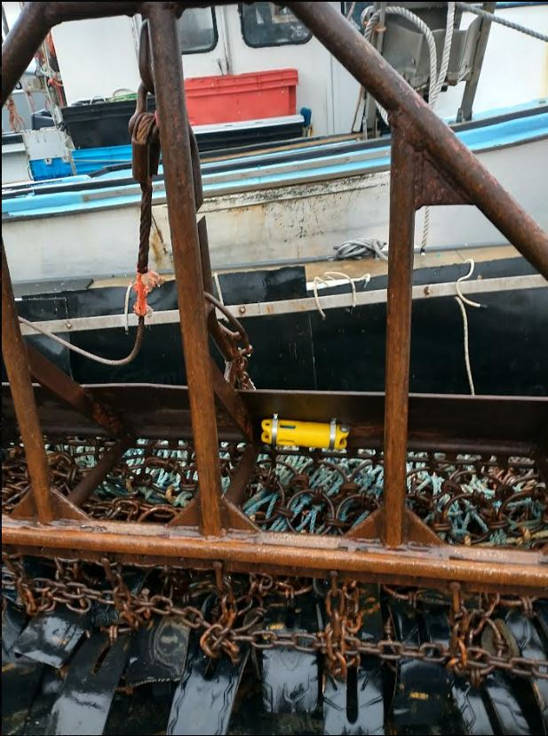

*Figure 1 – After running dissolved oxygen probes on his lobster traps all summer, we’ve swapped David Marsh’s F/V Grace Sarah over to a temperature profiler mounted on the dredge*

### Realtime Summary (Vessels with Rockblock Satellite Transmitters)

This week, we received 17 haul-averaged reports from 6 vessels.

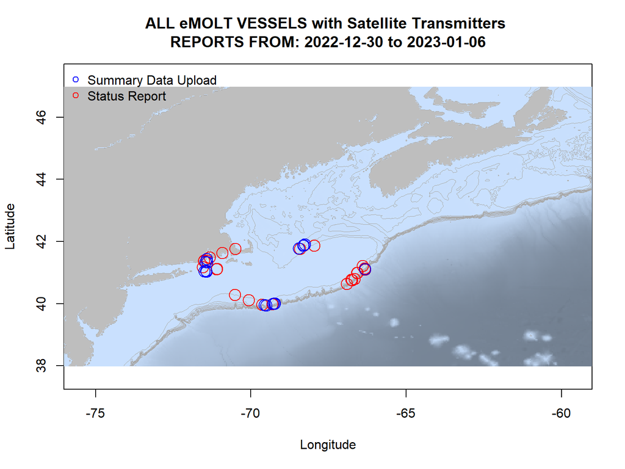

*Figure 2 - eMOLT Satellite Transmitter status plot for the previous week.* In the figure above, you can see the approximate locations where we received “Status Reports” (a ping from your system letting us know that it’s still working) and “Data Uploads” (actual temperature / depth data collected by your probes). The “Status Reports” come in every 12 hours or so when a system is powered up. “Data Uploads” only come in when you haul the probes. If you were out fishing and don’t see your approximate locations on here, please reach out because there may be a problem with your system.

### Announcements

- Thanks to captains Tony Alvernaz, Rob Martin, and Rodman Sykes who volunteered to participate in panel discussions about their fishing operations and their experience with environmental monitoring at the WHOI biogeochemical workshop in a few weeks.
- Thanks also to Joaquim Oller and Nick Lowell from Lowell Instruments who’ve hopped on the phone numerous times this week to help debug a few deckboxes remotely. If you’re having any issues with your eMOLT system, please reach out and let us know. You can call or text George at 508-299-9693 or send an email to george.maynard@noaa.gov
- We strive to be flexible so that we can keep up with our industry partners. If you fish multiple gears and want your eMOLT system to work regardless of which fishery you’re pursuing, let us know! We’re always happy to provide additional housings and sensors so that the data keeps flowing, no matter what else you’re catching.

All the best, -George and JiM